# Pengaruh Kategori Film terhadap Pendapatan pada Database Sakila

Husna Nafisha H

2026-05-26

# Deskripsi Data dan Insight

Dataset yang digunakan adalah Sakila Dataset yang berisi informasi mengenai actor, address, category, country, film, aktor film, kategori film, inventaris, bahasa, pembayaran, persewaan, staf, dan toko. Dalam analisis ini, variabel yang digunakan meliputi category, film_category, film, inventory, rental, dan payment.

Insight yang diambil adalah untuk melihat hubungan antara kategori film dan pendapatan, serta menganalisis pengaruh kategori film terhadap pendapatan pada database Sakila. Analisis ini bertujuan untuk mengetahui apakah kategori film tertentu memiliki pengaruh terhadap pendapatan.

# Persamaan Matematis

Total pendapatan kategori film dapat dihitung menggunakan persamaan:

$$Revenue = \sum_{i=1}^{n} Payment_i$$

Keterangan: - $Revenue$ = total pendapatan - $Payment_i$ = pembayaran ke-i - $n$ = jumlah transaksi rental

Rata-rata pendapatan dapat dihitung menggunakan rumus:

$$\bar{X} = \frac{\sum_{i=1}^{n} X_i}{n}$$

Keterangan: - $\bar{X}$ = rata-rata pendapatan - $X_i$ = nilai pendapatan - $n$ = jumlah kategori film

# Impor Data Sakila Dataset ke RStudio

```r
data <- read.csv("C:/Users/ASUS/OneDrive/Dokumen/Kategori Sakila/sakila_category.csv")
```

# Eksplorasi Data

```r
head(data)
```

```
##      category revenue
## 1      Action 4375.85
## 2   Animation 4656.30
## 3    Children 3655.55
## 4    Classics 3639.59
## 5      Comedy 4383.58
## 6 Documentary 4217.52
```

```r
str(data)
```

```
## 'data.frame':    16 obs. of  2 variables:
##  $ category: chr  "Action" "Animation" "Children" "Classics" ...
##  $ revenue : num  4376 4656 3656 3640 4384 ...
```

```r
summary(data)
```

```
##    category            revenue
##  Length:16          Min.   :3418
##  Class :character   1st Qu.:3706
##  Mode  :character   Median :4276
##                     Mean   :4213
##                     3rd Qu.:4435
##                     Max.   :5314
```

# Visualisasi Data

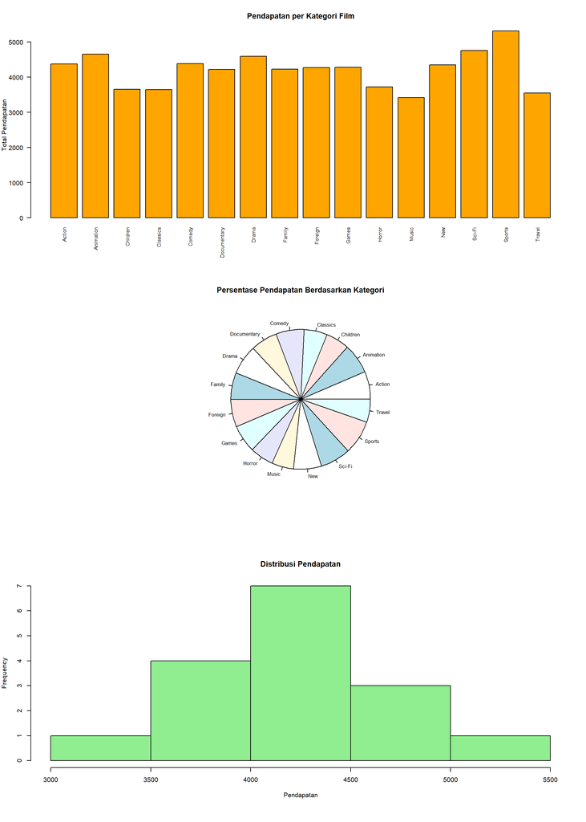

```r
par(mfrow = c(3,1),
    mar = c(7,4,4,2))

barplot(data$revenue,
        names.arg=data$category,
        las=2,
        col="orange",
        main="Pendapatan per Kategori Film",
        ylab="Total Pendapatan",
        cex.names=0.8)

pie(data$revenue,
    labels=data$category,
    main="Persentase Pendapatan Berdasarkan Kategori",
    cex=0.8)

hist(data$revenue,
     main="Distribusi Pendapatan",
     xlab="Pendapatan",
     col="lightgreen",
     border="black")
```

[output not shown]

# Interpretasi Visualisasi dan Analisis Data

Berdasarkan hasil analisis data pada database Sakila, diperoleh informasi mengenai pendapatan (*revenue*) dari masing-masing kategori film. Analisis dilakukan menggunakan metode deskriptif dengan bantuan visualisasi data berupa *bar chart*, *pie chart*, dan histogram.

Pada visualisasi *bar chart* terlihat bahwa setiap kategori film memiliki jumlah pendapatan yang berbeda-beda. Kategori **Sports** memiliki pendapatan tertinggi dibanding kategori lainnya dengan total revenue lebih dari 5.000 dolar. Hal ini menunjukkan bahwa kategori Sports merupakan kategori film yang paling banyak diminati pelanggan sehingga memberikan kontribusi terbesar terhadap pendapatan rental film. Selain kategori Sports, kategori seperti Sci-Fi, Animation, Drama, dan Comedy juga memiliki pendapatan yang relatif tinggi.

Sebaliknya, beberapa kategori seperti **Travel**, **Children**, **Music**, dan **Classics** memiliki revenue yang lebih rendah dibanding kategori lain. Hal ini menunjukkan bahwa tingkat penyewaan pada kategori tersebut relatif lebih sedikit sehingga kontribusi terhadap total pendapatan juga lebih kecil. Perbedaan revenue antar kategori dapat dipengaruhi oleh popularitas genre film, preferensi pelanggan, maupun jumlah transaksi rental pada masing-masing kategori.

Berdasarkan visualisasi *pie chart*, terlihat bahwa distribusi persentase pendapatan antar kategori film cenderung cukup beragam. Kategori dengan pendapatan tinggi memiliki potongan diagram yang lebih besar dibanding kategori lainnya. Namun secara keseluruhan, perbedaan antar kategori tidak terlalu ekstrem sehingga menunjukkan bahwa hampir semua kategori tetap memberikan kontribusi terhadap total revenue perusahaan rental film.

Pada histogram distribusi pendapatan terlihat bahwa sebagian besar kategori film memiliki pendapatan pada kisaran sekitar 3.500 hingga 4.500 dolar. Hal ini menunjukkan bahwa distribusi revenue antar kategori cukup terpusat pada rentang tertentu dan tidak terdapat perbedaan yang terlalu jauh antar kategori. Selain itu, hanya terdapat sedikit kategori yang memiliki pendapatan sangat tinggi maupun sangat rendah.

Hasil analisis deskriptif menunjukkan bahwa terdapat variasi pendapatan pada setiap kategori film. Nilai revenue tertinggi menunjukkan kategori yang paling menguntungkan, sedangkan revenue terendah menunjukkan kategori dengan kontribusi pendapatan paling kecil. Analisis ini memberikan gambaran mengenai pola minat pelanggan terhadap genre film tertentu.

Dari sisi bisnis, hasil analisis ini dapat digunakan sebagai bahan pertimbangan dalam menentukan strategi pengelolaan film. Kategori dengan revenue tinggi dapat diprioritaskan untuk penambahan koleksi, promosi, maupun pengembangan layanan karena memiliki potensi menghasilkan pendapatan lebih besar. Sementara itu, kategori dengan revenue rendah dapat dievaluasi lebih lanjut untuk mengetahui faktor penyebab rendahnya minat pelanggan.

Dengan demikian, analisis visualisasi dan data pada database Sakila memberikan insight bahwa kategori film memiliki hubungan terhadap besar kecilnya pendapatan yang diperoleh perusahaan rental film. Preferensi pelanggan terhadap genre tertentu berpengaruh terhadap jumlah transaksi rental dan total revenue yang dihasilkan.